# 经济指标Ⅰ：GDP

### 4.11978-2000年

先看1978-2000年。这个阶段中国GDP年均复合增速约为9.7%，是历史上增速较快的阶段。最主要的原因即是改革开放后，体制束缚逐渐解除，中国经济增长活力被彻底激发。

但同时，这个阶段也出现了几次比较大的波动。波动的主要原因，在于中央经济政策的松紧。我们将这个阶段分为6个小阶段来看。

第一，1978-1981年GDP增速下滑。

主要是因为中央判断投资过热，物资缺口过大，所以决定在1979-1981年进行经济调整，通过项目限制、信贷管制等方式，压缩固定资产投资规模。该时期，投资对GDP的拉动点数下滑得非常快。

第二，1982-1985年GDP增速高增。该时期无论是生产还是需求都在快速扩张。

生产端，政策逐步催化。

1）1982年，中央提出20世纪末工农业产值“翻两番”计划，带动了生产热情。

2）家庭联产承包责任制全面铺开，这个制度极大地解放了农业生产力，第一产业GDP拉动点数，较上个阶段有所扩大。

3）一旦农村剩余劳动力增多，加上户籍制度松绑，人口便流向城市，为城市工业、服务业输血。所以第二产业、第三产业GDP拉动点数也在扩大。

需求端，消费+投资双热。

1）工资制度改革，职工工资和企业利润挂钩，很多企业大幅度提高工人的工资和奖金，可以看到下图中，平均实际工资指数快速上升，这带动了消费需求扩张，1984年消费对GDP拉动点数甚至冲高到10个点。

2）一些地方为了加快完成工业翻两番计划，大力扩建工业产能，另外价格双轨制下，企业为了获取计划外的利润，也有动力扩产，进而拉动投资走高。

3）这段时期进口增速远超出口增速，导致净出口对GDP拉动作用持续为负，1985年甚至降至负7个点，这也反映了内需增长较快。

{{% center %}}

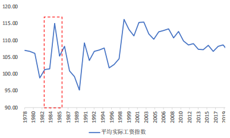

{{% /center %}}

1983-1984年平均实际工资指数突然提升

{{% center %}}

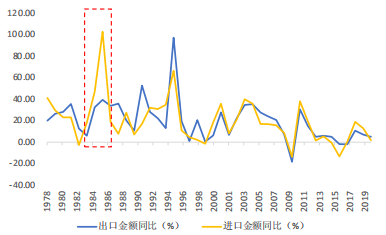

{{% /center %}}

第三，1986-1991年GDP增速向下调整，主要是因为政府在1985年下半年、1988年两度选择了收紧经济政策。

1985年，消费、投资需求都扩张得很厉害，经济过热导致通胀升温。1985年政府其实纠结了很久，是继续推经济，还是防通胀。最后在下半年得出了基本结论：防通胀。并采取了一些措施，比如控制货币供应量，收缩信贷，限制职工工资奖金等。

但因为1986年1季度的经济大滑坡，导致中央防通胀决心有所动摇，2季度重新放开信贷规模，投资需求又再度膨胀，带动1987-1988年GDP增速回升。同时，1988年中央又决定冒险实现价格闯关，改革价格双轨制。需求扩张+制度突然调整，结果导致通胀迅速升起。

{{% center %}}

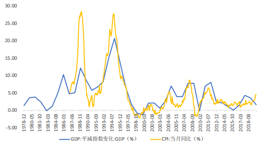

{{% /center %}}

1988年中国通货膨胀高企

最终，中央在1988年决定，用三年时间进行全面治理整顿，维护经济秩序，不惜通过经济硬着陆的方式实现。

在整顿期， 中央紧缩财政信贷、压缩投资，虽然控制了通胀，但也付出了相当沉重的经济代价，GDP增速从两位数掉到了4%左右。到1991年底，经济秩序整顿基本完成，中央开始加大投资规模，重启经济，中国经济也逐渐走出了低谷。

第四，1992-1993年GDP增速上行。 主要是因为1992年邓小平南方谈话后，短期内全国又掀起了新一轮的改革高潮，发展市场经济的理念不再动摇，这也刺激了当时的投资和消费热情，两者对GDP的拉动作用在1992-1993年都非常高。

另外，南方谈话后，允许外资在中国投资兴办企业，上海浦东、沿江沿边内陆等进一步开放，外商直接投资规模迅速扩大。也成为了该时期经济增长的重要驱动力之一。

{{% center %}}

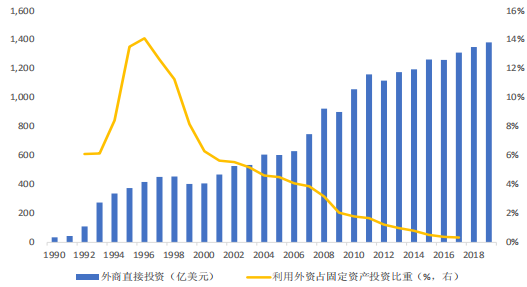

{{% /center %}}

南方谈话后，外商直接投资规模快速扩张

第五，1994-1997年GDP增速下行。

主要是因为南方谈话后，总需求又开始过热，货币发行和信贷扩张，进而明显加大了通货膨胀压力。因此1993年6月开始，中央加强了宏观调控，推动GDP增速软着陆。历史在重演，只是这次更有序一些。

第六，1997-2001年GDP增速继续下行。主要受97年亚洲金融危机影响。

一方面，亚洲金融危机期间，中国承诺人民币不贬值，出口受较大影响。同时外资也在撤退，影响了投资增速，经济下行压力加大。

不过另一方面，我国也出台了一系列措施来拉动内需。比如发行长期建设国债，加大基础设施建设投资；通过减税、增加农业补贴等措施提高居民收入，进而增加消费。

有了逆周期政策的对冲，尽管遭遇了亚洲金融危机冲击，中国GDP增速没有出现大幅滑落。

总体来看，1978-2000年这段时期，政策对经济运转节奏的影响非常大，几乎是“一松就热，一紧就死”。这主要是因为中国正处于迈向市场经济的转轨阶段，各种调控手段还不够完善。

另外，这段时期频繁出现的经济过热现象、高通胀现象，其实也反映了当时的经济矛盾，主要是生产能力跟不上需求扩张。

不过到了90年代末期，各种制度改革已经取得了很大成效，生产力解放，供给约束基本被打开，供不应求的矛盾逐渐向供过于求过渡。这从两个方面可以看出：一是通胀的平均值下沉，很少再出现需求相对供给明显过热，导致通胀高企的情况。二是中国的贸易顺差越拉越大，说明溢出的生产能力被国外需求消耗了。

### 4.22001-2011年

接下来看2001-2012年，这一段时间，中国经济增长与全球的联系逐渐紧密。

第一，2001-2007年GDP增速持续上行。

2001年末，中国顺利加入了世贸组织，这是中国经济在2001-2007年扭转下滑态势、进入新一轮上升期的核心动力。

这段时期，由于贸易条件双向开放，其实中国的进口和出口都在快速增长，所以最终的净出口对GDP的拉动效应其实并不明显。该阶段GDP增长的逻辑主要在于：

1）出口增加和外需扩张，刺激了我国生产，特别是工业生产，使得中国成为世界工厂。可以看到第二产业对GDP拉动点数在2001-2007年，一直在持续提升。

2）企业产能扩张，因此投资维持在一个比较高的水平。此外，贸易顺差下带来的大量外汇储备，推动了基础货币投放，也给投资创造了比较好的流动性条件。

3）出口创收，增加了居民财富，也带动了消费扩张。

4）而消费扩张，又带动了许多不可贸易部门的生产，这些不可贸易部门很多集中在第三产业，因此第三产业的GDP拉动点数也在稳步提升。

第二，2008-2012年GDP增速出现大幅波动，主要是受08年全球金融危机、以及后续的中国经济刺激政策影响。

2008年全球金融危机爆发，海外发达经济陷入深度衰退，外需收缩，出口减速，企业生产放缓，扩产投资意愿低迷，就业压力增大，消费萎缩。这一系列因素，明显增大了我国经济压力，因此2018年GDP增速放缓。

金融危机的影响逐步显现，我国出台了一系列政策来刺激经济，例如货币政策宽松，多次下调存款准备金率、存贷款基准利率等。而其中最著名的是“4万亿投资计划”，这些资金主要投向基础设施领域，目的是通过政府财政刺激拉动总需求，进而来保障经济增长。

可以看到，2009年投资对GDP的拉动点数大增至8个点，有效对冲了净出口下滑带来的负面影响，成为GDP增长最主要的支撑力量。

而在主要的投资类别中，基建又是最主要支撑。2009年房地产投资、制造业企业投资都在下滑，只有基建投资逆势抬升，这显然是政府财政刺激的结果。

{{% center %}}

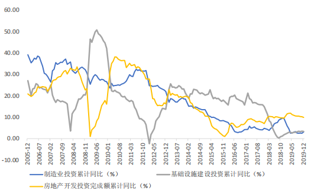

{{% /center %}}

2009年，财政刺激下的基建投资成为中国经济的主要支撑力量

政策刺激起到了显著效果。我国GDP在2008-2011年间依旧保持了9%以上的增长，成为了全球率先实现复苏的国家。

但是不考虑剂量的政策刺激，也给中国经济留下了许多后遗症：

1）实体经济杠杆水平抬升。巨额的基建投资，带来了严重的地方政府隐性债务问题。另外在货币宽松环境下，企业的加杠杆行为也非常严重，债务率迅速走高。债务驱动经济增长，其实是在透支未来的发展空间。

2）房地产库存积压。货币极度宽松、信贷扩张、调控政策放松、以及而流动性泛滥下的房价快速上涨，都催化着房地产投资在2009年以来迅速升温，给之后的房地产库存积压埋下伏笔。

3）上游企业产能过剩。基建、地产投资扩张，带动钢铁、水泥等上游产能扩容，结果造成了后来严重的产能过剩问题。

因此，表面上看，中国GDP还维持着较高增速，但2008年金融危机后，其实已经隐藏着许多结构性的问题，这也是为什么后来国家要推行去杠杆、去库存、去产能的重要原因。

### 4.32012年至今

最后来看2012年至今。这段时期，GDP增速持续放缓，经济增长进入新常态。

2012年GDP跌破8%，基本已经告别两位数增长时代，而到了2019年，GDP已经下行至6.1%。

该时期GDP增速下台阶的原因是多方面的：

第一，海外经济体还处于08年金融危机的余震中，外部需求仍然比较疲软，全球化红利逐渐衰退。

第二，中国经济内部的一些结构性问题逐渐暴露，而我国也主动放缓经济增长步伐，更注重发展质量，开始积极地化解这些内在问题。

第三，许多支撑中国经济高增长的长期因素，正在悄然发生变化，比如人口结构的变迁。

具体来看，需求端方面，投资的弱化成为拖累GDP下行的主要因素。

一方面，在08年大规模的投资刺激之后，投资边际效率下滑，同时各部门债务率高企，追加投资的意愿和能力都比较有限。

另一方面，我国为了防范金融风险和债务风险，也不再像之前一样，总是依赖强刺激政策拉动经济增长，而是坚定不走大水漫灌的老路。 这些因素加在一起，带来了当前投资力量的弱化。

由于投资的低迷可能成为常态，外部需求又难言好转，甚至在中美贸易摩擦、逆全球化抬头的当下，有进一步恶化的趋势。所以拉动消费的重要性越来越凸显，这就需要保障就业，提高居民收入，并且稳住居民杠杆率。

而生产端方面，第二产业或者说工业生产，正面临瓶颈期。

从长期因素来看，中国人口红利不再，取而代之的将是越来越严重的老龄化问题，这可能会带来劳动力要素的供给限制。另外，资源、环境的约束也在逐渐加强。因此像以前一样，用低成本扩张工业生产特别是劳动密集型、资源密集型工业生产的方式，很难继续。

从相对短期的因素来看，金融危机和一揽子刺激计划后，我国企业面临着比较严峻的产能过剩问题，尤其是一些上游企业。因此我国开启了去产能进程，关闭和停产了大量企业，这也对工业生产造成了较大影响。

不过，这段时期中国的服务业扩张的很快。2015年第三产业占GDP比重首次超过50%，并且还在不断扩张，从全球发达经济体的历史经验来看，这其实是一个必然趋势。

再跳出一二三产业的概念范畴来看，高科技产业和新经济的崛起，可能是未来中国GDP增长的主要驱动力。所以中国目前也在集中力量推动科技创新，推动经济新旧动能转换。用技术进步的力量，来对抗劳动力和资本要素的退场。

{{% center %}}

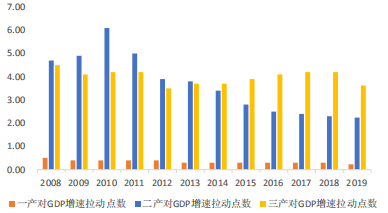

{{% /center %}}

第二产业对GDP拉动点数下滑，第三产业成为主要支撑力量

{{% center %}}

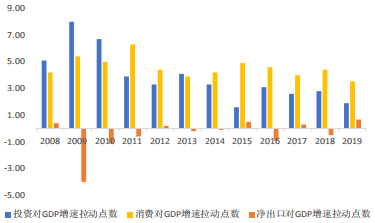

{{% /center %}}

投资对 GDP 拉动点数下滑，消费成为主要支撑力量

2020年新冠疫情的爆发，给经济蒙上了一层新的阴影。1季度GDP增速大幅跌落至-6.8%。

为了控制新冠疫情，我国采取了物理隔离措施，企业停产停工，这就直接对生产端造成了非常大的冲击，其中工业生产受到的冲击尤为严重，第二产业GDP同比甚至降至-9.6%。

同时，新冠疫情对总需求也产生了较大影响。由于居民出行意愿下滑、就业形势恶化等原因，消费受到较大冲击。而经济前景不明朗、现金流压力较大，库存积压的情况下，企业也不愿意追加投资。1季度的最终消费支出和资本形成总额对GDP同比的拉动点数，分别下滑到-4.36和-1.46个百分点。